# DSC450-T301 - Project 2: Project Draft Group Assignment (Milestone 2)

**Professor**: Fadi Alsaleem  
**@Copyright**: BELLEVUE.edu  
**OS**: Windows 11 x64  
**Processor**: i9-13900  
**GPU**: NVIDIA GeForce RTX 5080  
**IDE**: VS Code  
**Interpreter**: Python 3.13  
**Libraries Managed by**: Miniforge3

**Team Roles**:

1. **Data Wrangler**: Delilah Slabaugh  
   **Responsibilities**:
- Data acquisition
- Cleaning
- Transformation
- Quality Assessment
2. **Data Scientist**: Tyler Heflin  
   **Responsibilities**:
- Data exploration
- Model Development
- Analysis
- Recommendations
3. **Data Visualizer**: Carlos Escamilla  
   **Responsibilities**:
- Create visualizations
4. **Data Presenter**: Andres Melendez  
   **Responsibilities**:
- Presentation Design
- Storytelling

**Version**:

- 1.0.0 - 2025.06.30 Week5 - Milestone 1: Proposal and Data Selection Group Assignment
- 1.0.1 - 2025.07.07 Week6 - Milestone 2: Project Draft Group Assignment
- 1.0.1 - 2025.07.14 Week7 - Milestone 3: Presentation and Team Evaluation

**Resources**:

- [IMDB Large Movie Review Dataset](https://ai.stanford.edu/~amaas/data/sentiment/)

# DATA WRANGLER

**Author**:  
Delilah Slabaugh

### Import Libraries

Importing all the libraries needed to clean the IMDB dataset. I use pandas for handling the data, re for regular expressions, and nltk for natural language tasks like tokenizing and lemmatizing. I import stopwords, WordNetLemmatizer, and word_tokenize to remove common words and get base word forms. Lastly, I bring in contractions to expand words like “can’t” to “cannot” to make the text clearer for processing.

```python
#importing needed libraries
import pandas as pd
import re
import nltk
from nltk.corpus import stopwords
from nltk.stem import WordNetLemmatizer
from nltk.tokenize import word_tokenize
import contractions
```

### Download NLTK Resources

Downloading the NLTK resources needed for the cleaning steps. This includes the stopwords list, the punkt tokenizer for splitting text into words, and the WordNet and OMW packages that help with lemmatizing words to their base forms. Running this ensures I have all the language data ready for processing the IMDB reviews.

```python
#downloading stopwords, tokenizers, and wordnet data
nltk.download('stopwords')
nltk.download('punkt_tab')
nltk.download('wordnet')
nltk.download('omw-1.4')
nltk.download('averaged_perceptron_tagger_eng')
```

```
True
```

### Load Dataset

Loading the IMDB dataset CSV file from the downloads folder and saving it to a DataFrame called df. After loading it, I’m printing a message and displaying the first few rows so I can check that the data loaded correctly and see how the raw reviews and sentiment labels look before cleaning.

```python
#loading imdb dataset from downloads folder
df = pd.read_csv('Data/IMDBDataset.csv')

#showing first rows
print('original dataset:')
print(df.head())
```

```
original dataset:
                                              review sentiment
0  One of the other reviewers has mentioned that ...  positive
1  A wonderful little production. <br /><br />The...  positive
2  I thought this was a wonderful way to spend ti...  positive
3  Basically there's a family where a little boy ...  negative
4  Petter Mattei's "Love in the Time of Money" is...  positive
```

### Drop Null Values

Removing any rows in the dataset that contain null values to make sure the data is clean and complete. Before dropping the nulls, I save the shape of the DataFrame to see how many rows and columns there are. After dropping and resetting the index, I check the shape again and print both shapes so I can confirm if any rows were actually removed.

```python
#dropping rows with null values
before_nulls = df.shape
df = df.dropna().reset_index(drop=True)
after_nulls = df.shape

#printing shape change
print(f'shape before removing nulls: {before_nulls}')
print(f'shape after removing nulls: {after_nulls}')
```

```
shape before removing nulls: (50000, 2)
shape after removing nulls: (50000, 2)
```

### Drop Duplicates

Removing any duplicate reviews from the dataset to make sure each review is unique. I first check and save the shape of the DataFrame before dropping duplicates, then I drop duplicates based on the review column and reset the index. After that, I check the shape again and print both shapes so I can see how many duplicate rows were removed.

```python
#dropping duplicate reviews
before_dupes = df.shape
df = df.drop_duplicates(subset='review').reset_index(drop=True)
after_dupes = df.shape

#printing shape change
print(f'shape before removing duplicates: {before_dupes}')
print(f'shape after removing duplicates: {after_dupes}')
```

[output not shown]

### Create Function: Clean_Text_Advanced

Setting up the stop words list and the lemmatizer so I can filter out common words and reduce words to their base form later. Then, I define a function called clean_text_advanced that handles the main cleaning tasks. This function expands contractions like “don’t” to “do not,” removes any HTML tags and non-letter characters, converts the text to lowercase, tokenizes it into individual words, removes stop words, and lemmatizes each word. Finally, it joins the cleaned words back into a single string to get a cleaned version of each review.

```python
#setting stop words and lemmatizer
stop_words = set(stopwords.words('english'))
lemmatizer = WordNetLemmatizer()

#defining function for expanding contractions, cleaning text, removing stopwords, and lemmatizing
def clean_text_advanced(text):
    text = contractions.fix(text)
    text = re.sub(r'<.*?>', '', text)
    text = re.sub(r'[^a-zA-Z ]', '', text)
    text = text.lower()
    words = word_tokenize(text)
    words = [lemmatizer.lemmatize(w) for w in words if w not in stop_words]
    return ' '.join(words)
```

### Clean Text

Applying the clean_text_advanced function to every review in the dataset to create a new column called cleaned_review. This runs all the text cleaning steps for each row. After that, I’m printing out a sample of the original reviews next to their cleaned versions so I can quickly see how the text has been transformed and make sure the cleaning worked as expected.

```python
#applying cleaning function to reviews
df['cleaned_review'] = df['review'].apply(clean_text_advanced)

#printing sample cleaned reviews
print('sample cleaned reviews:')
print(df[['review', 'cleaned_review']].head())
```

```
sample cleaned reviews:
                                              review  \
0  One of the other reviewers has mentioned that ...
1  A wonderful little production. <br /><br />The...
2  I thought this was a wonderful way to spend ti...
3  Basically there's a family where a little boy ...
4  Petter Mattei's "Love in the Time of Money" is...

                                      cleaned_review
0  one reviewer mentioned watching oz episode hoo...
1  wonderful little production filming technique ...
2  thought wonderful way spend time hot summer we...
3  basically family little boy jake think zombie ...
4  petter matteis love time money visually stunni...
```

### Display Clean Text

Displaying a random sample of five cleaned reviews from the cleaned_review column. This helps me quickly double-check that the cleaning function worked well across different parts of the dataset and that the text looks consistent and ready for further analysis.

```python
#showing random cleaned sample
print('more cleaned samples:')
print(df[['cleaned_review']].sample(5))
```

```
more cleaned samples:
                                          cleaned_review
42315  start box enough keep away attempt would taugh...
17579  chesty gringo telly savalas frank cooper usmex...
18704  parading around yearold girl thong swimsuit on...
9420   pure gothic vampire cheese nothing compare sub...
47467  excellent movie presented every year holiday c...
```

### Save to CSV Cleaned Dataset

Saving the cleaned dataset as a new CSV file called IMDBDataset_cleaned.csv in the downloads folder. After saving it, I print a confirmation message so I know the cleaned file was created successfully and is ready to use for modeling or analysis.

```python
#saving cleaned dataset to downloads folder
df.to_csv('IMDBDataset_cleaned.csv', index=False)

#printing confirmation
print('cleaned dataset saved to Downloads/IMDBDataset_cleaned.csv')
```

```
cleaned dataset saved to Downloads/IMDBDataset_cleaned.csv
```

# DATA SCIENTIST

**Description**:  
Feature engineering (TF-IDF, POS tagging), Baseline modeling (Logistic Regression with GridSearchCV and Random Forest Classifiers), Advanced modeling (DistilBERT with Hugging Face), Comprehensive evaluation (metrics, confusion matrix, ROC), Explainability (SHAP and feature importance), prelimiary visualizations (word clouds, feature insights)

**Data Scientists**:  
Tyler Heflin

### Load Dataset

Here, the preprocessed dataset (IMDBDataset_cleaned.csv) is loaded into memory for feature extraction and modeling. Proper structure and data integrity checks ensure consistent input downstream.

```python
# Load cleaned dataset
df = pd.read_csv("Data/IMDBDataset_cleaned.csv")

# Display first few records
print(df.head())

# Check class distribution
print(df['sentiment'].value_counts())
```

```
                                              review sentiment  \
0  One of the other reviewers has mentioned that ...  positive
1  A wonderful little production. <br /><br />The...  positive
2  I thought this was a wonderful way to spend ti...  positive
3  Basically there's a family where a little boy ...  negative
4  Petter Mattei's "Love in the Time of Money" is...  positive

                                      cleaned_review
0  one reviewer mentioned watching oz episode hoo...
1  wonderful little production filming technique ...
2  thought wonderful way spend time hot summer we...
3  basically family little boy jake think zombie ...
4  petter matteis love time money visually stunni...
sentiment
positive    24884
negative    24698
Name: count, dtype: int64
```

### Feature Engineering

Text is converted into numerical representations so models can learn. For this step, we use:

- TF-IDF for word frequency and importance
- POS tagging for syntactic context

Numerical representation is needed to train classifiers. TF-IDF is fast and effective (especially when data is sparse), then POS tagging can enrich context. Additionally, logistic regression (which we will use later) performs well on TF-IDF features in sentiment tasks and POS-based features can enhance signal for sentiment polarity.

```python
from sklearn.feature_extraction.text import TfidfVectorizer
from nltk import pos_tag, word_tokenize
from sklearn.preprocessing import MinMaxScaler
import scipy

# Encode binary labels (1 = positive, 0 = negative)
df['label'] = df['sentiment'].map({'positive': 1, 'negative': 0})

# TF-IDF vectorization
tfidf_vectorizer = TfidfVectorizer(max_features=5000, ngram_range=(1, 2))
X_tfidf = tfidf_vectorizer.fit_transform(df['cleaned_review'])

# POS tagging to count adjectives and adverbs
def count_pos_tags(text):
  tags = [tag for word, tag in pos_tag(word_tokenize(text))]
  return tags.count('JJ') + tags.count('RB')

df['pos_count'] = df['cleaned_review'].apply(count_pos_tags)

# Normalize and combine TF-IDF and POS features
pos_scaled = MinMaxScaler().fit_transform(df[['pos_count']])
X_final = scipy.sparse.hstack((X_tfidf, pos_scaled))
y = df['label']
```

### Baseline Modeling (Logistic Regression and GridSearchCV)

A baseline model is trained using logistic regression and hyperparameters are tuned for best performance. This model is fast and performs well on high-dimensional sparse data like TF-IDF matrices but is ideal for text classification. GridSearchCV is used to find the optimal C value which increases generalization while reducing overfitting. A confusion matrix, classification report, and SHAP explainability are also provided to assess model performance and feature importance.

```
Best Parameters: {'C': 1}
              precision    recall  f1-score   support

    Negative       0.89      0.88      0.88      4940
    Positive       0.88      0.90      0.89      4977

    accuracy                           0.89      9917
   macro avg       0.89      0.89      0.89      9917
weighted avg       0.89      0.89      0.89      9917
```

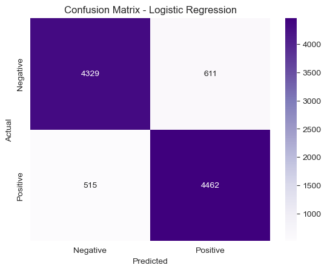

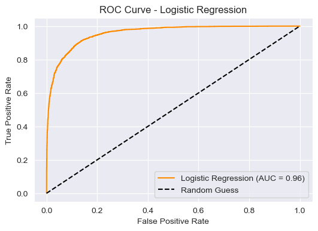

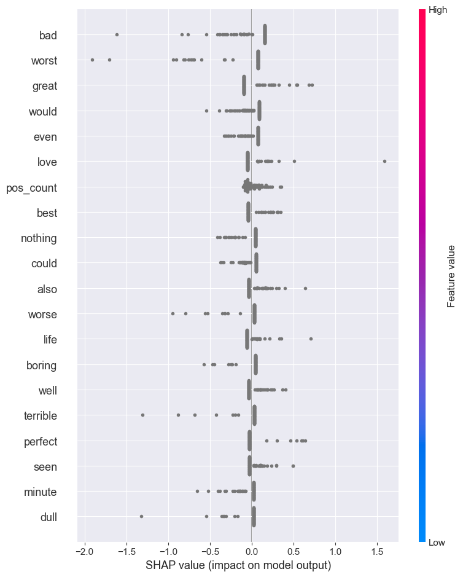

```python
from sklearn.model_selection import train_test_split, GridSearchCV
from sklearn.linear_model import LogisticRegression
from sklearn.metrics import classification_report, confusion_matrix, roc_curve, auc, RocCurveDisplay
import seaborn as sns
import matplotlib.pyplot as plt
import shap

# Train test split
X_train, X_test, y_train, y_test = train_test_split(X_final, y, test_size=0.2, random_state=42, stratify=y)

# Grid search over regularization parameter
param_grid = {'C': [0.1, 1, 10]}
grid = GridSearchCV(LogisticRegression(max_iter=1000), param_grid, cv=5, scoring='f1')
grid.fit(X_train, y_train)

# Evaluate
y_pred = grid.predict(X_test)
print("Best Parameters:", grid.best_params_)
print(classification_report(y_test, y_pred, target_names=["Negative", "Positive"]))

# Confusion Matrix
cm = confusion_matrix(y_test, y_pred)
sns.heatmap(cm, annot=True, fmt='d', cmap='Purples', xticklabels=["Negative", "Positive"], yticklabels=["Negative", "Positive"])
plt.title("Confusion Matrix - Logistic Regression")
plt.xlabel("Predicted")
plt.ylabel("Actual")
plt.show()

# ROC Curve
y_prob_lr = grid.predict_proba(X_test)[:, 1]

fpr_lr, tpr_lr, _ = roc_curve(y_test, y_prob_lr)
roc_auc_lr = auc(fpr_lr, tpr_lr)

plt.figure(figsize=(6, 4))
plt.plot(fpr_lr, tpr_lr, label=f"Logistic Regression (AUC = {roc_auc_lr:.2f})", color='darkorange')
plt.plot([0, 1], [0, 1], 'k--', label='Random Guess')
plt.xlabel("False Positive Rate")
plt.ylabel("True Positive Rate")
plt.title("ROC Curve - Logistic Regression")
plt.legend(loc="lower right")
plt.grid(True)
plt.show()

# SHAP Explainability
explainer = shap.Explainer(grid.best_estimator_, X_train)
shap_values = explainer(X_test[:100])

# Add POS count feature name
feature_names_with_pos = list(tfidf_vectorizer.get_feature_names_out()) + ['pos_count']

# Summary Plot
shap.summary_plot(shap_values, X_test[:100], feature_names=feature_names_with_pos)
```

## Baseline Modeling (Random Forest Classifier)

```
              precision    recall  f1-score   support

    Negative       0.85      0.84      0.84      4940
    Positive       0.84      0.85      0.85      4977

    accuracy                           0.85      9917
   macro avg       0.85      0.85      0.85      9917
weighted avg       0.85      0.85      0.85      9917
```

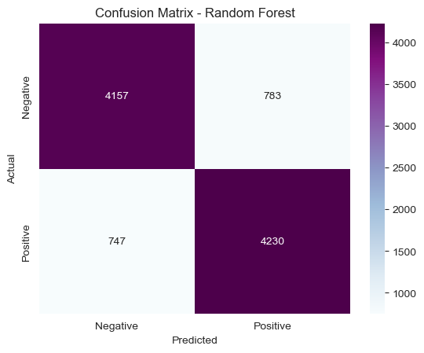

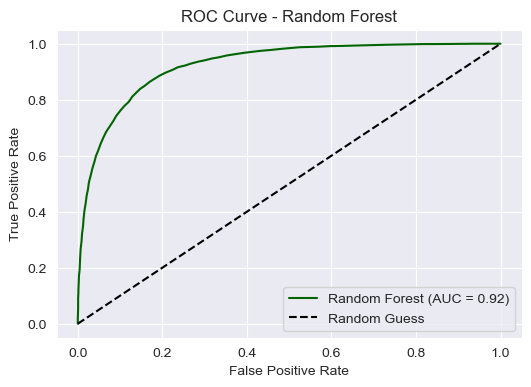

```python
from sklearn.ensemble import RandomForestClassifier
import shap
import matplotlib.pyplot as plt
import seaborn as sns
from sklearn.metrics import classification_report, confusion_matrix

# Train RF Model
rf_model = RandomForestClassifier(n_estimators=100, random_state=42, n_jobs=-1)
rf_model.fit(X_train, y_train)

# Predict
rf_preds = rf_model.predict(X_test)

# Classification Report
print(classification_report(y_test, rf_preds, target_names=["Negative", "Positive"]))

# Confusion Matrix
cm_rf = confusion_matrix(y_test, rf_preds)
sns.heatmap(cm_rf, annot=True, fmt='d', cmap='BuPu', xticklabels=["Negative", "Positive"], yticklabels=["Negative", "Positive"])
plt.title("Confusion Matrix - Random Forest")
plt.xlabel("Predicted")
plt.ylabel("Actual")
plt.show()

# ROC Curve
y_prob_rf = rf_model.predict_proba(X_test)[:, 1]

fpr_rf, tpr_rf, _ = roc_curve(y_test, y_prob_rf)
roc_auc_rf = auc(fpr_rf, tpr_rf)

plt.figure(figsize=(6, 4))
plt.plot(fpr_rf, tpr_rf, label=f"Random Forest (AUC = {roc_auc_rf:.2f})", color='darkgreen')
plt.plot([0, 1], [0, 1], 'k--', label='Random Guess')
plt.xlabel("False Positive Rate")
plt.ylabel("True Positive Rate")
plt.title("ROC Curve - Random Forest")
plt.legend(loc="lower right")
plt.grid(True)
plt.show()
```

### Baseline Model Comparison

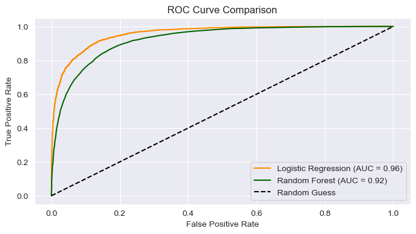

```python
plt.figure(figsize=(8, 4))
plt.plot(fpr_lr, tpr_lr, label=f"Logistic Regression (AUC = {roc_auc_lr:.2f})", color='darkorange')
plt.plot(fpr_rf, tpr_rf, label=f"Random Forest (AUC = {roc_auc_rf:.2f})", color='darkgreen')
plt.plot([0, 1], [0, 1], 'k--', label='Random Guess')
plt.xlabel("False Positive Rate")
plt.ylabel("True Positive Rate")
plt.title("ROC Curve Comparison")
plt.legend(loc="lower right")
plt.grid(True)
plt.show()
```

### Advanced Modeling (DistilBERT)

A deep contextual language model is then trained to classify sentiment based on semantic and syntactic patterns. Transformer models (like BERT) can understand context and word meaning better than traditional approaches. DistilBERT was used as a lightweight variant to BERT as it performs well with fewer resources and fine-tuning is simplified through Hugging Face.

```python
from transformers import DistilBertTokenizerFast, DistilBertForSequenceClassification, Trainer, TrainingArguments
from datasets import Dataset

# Split raw reviews and labels for fine-tuning
from sklearn.model_selection import train_test_split
train_texts, test_texts, train_labels, test_labels = train_test_split(df['review'].tolist(), df['label'].tolist(), test_size=0.2)

# Tokenize
tokenizer = DistilBertTokenizerFast.from_pretrained('distilbert-base-uncased')
train_encodings = tokenizer(train_texts, truncation=True, padding=True)
test_encodings = tokenizer(test_texts, truncation=True, padding=True)

# Convert to Hugging Face Dataset
train_dataset = Dataset.from_dict({**train_encodings, 'label': train_labels})
test_dataset = Dataset.from_dict({**test_encodings, 'label': test_labels})

# Load model
model = DistilBertForSequenceClassification.from_pretrained("distilbert-base-uncased", num_labels=2)

# Define training params
training_args = TrainingArguments(
    output_dir="./results",
    eval_strategy="epoch",
    save_strategy="epoch",  # Added to match eval_strategy
    learning_rate=2e-5,
    per_device_train_batch_size=32,
    per_device_eval_batch_size=64, # Corrected typo
    num_train_epochs=3,
    weight_decay=0.01,
    logging_dir="./logs",
    logging_steps=50,  # Added back
    save_total_limit=2,  # Added back
    load_best_model_at_end=True, # Added back
    fp16=True # Added back
)

# Train
trainer = Trainer(
    model=model,
    args=training_args,
    train_dataset=train_dataset,
    eval_dataset=test_dataset
)

trainer.train()
```

```
Some weights of DistilBertForSequenceClassification were not initialized from the model checkpoint at distilbert-base-uncased and are newly initialized: ['classifier.bias', 'classifier.weight', 'pre_classifier.bias', 'pre_classifier.weight']
You should probably TRAIN this model on a down-stream task to be able to use it for predictions and inference.
```

[3720/3720 09:26, Epoch 3/3]

| Epoch | Training Loss | Validation Loss |
| --- | --- | --- |
| 1 | 0.197400 | 0.198066 |
| 2 | 0.125200 | 0.194591 |
| 3 | 0.075400 | 0.240518 |

```
TrainOutput(global_step=3720, training_loss=0.1522160223094366, metrics={'train_runtime': 567.5709, 'train_samples_per_second': 209.657, 'train_steps_per_second': 6.554, 'total_flos': 1.576295810307072e+16, 'train_loss': 0.1522160223094366, 'epoch': 3.0})
```

```
Final evaluation metrics: {'eval_loss': 0.19459053874015808, 'eval_runtime': 13.0332, 'eval_samples_per_second': 760.905, 'eval_steps_per_second': 11.893, 'epoch': 3.0}
```

```
<sklearn.metrics._plot.confusion_matrix.ConfusionMatrixDisplay at 0x274880d68d0>
```

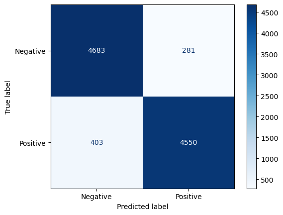

```python
# Final evaluation
metrics = trainer.evaluate()
print("Final evaluation metrics:", metrics)

# Save model
trainer.save_model("./final_model")
tokenizer.save_pretrained("./final_model")

# Plot confusion matrix
from sklearn.metrics import confusion_matrix, ConfusionMatrixDisplay
predictions = trainer.predict(test_dataset)
y_true = predictions.label_ids
y_pred = predictions.predictions.argmax(-1)
cm = confusion_matrix(y_true, y_pred)
ConfusionMatrixDisplay(confusion_matrix=cm, display_labels=["Negative", "Positive"]).plot(cmap='Blues')
```

**Interpretations**

1. Confusion Matrix
- True Negative: 4683 | False Positive: 281
- False Negative: 403 | True Positive: 4550
- Outstanding precision and recall
- Only 684 *total* misclassifications; an improvement over both logisitic regression and random forest
2. Evaluation Metrics
- Evaluation Loss: ~0.195
- Evaluation Speed: 760 samples per second with current setup
- This model is learning nuanced semantic patterns that the other models could not pick up

### Visualization (Word Clouds and EDA)

Here, word usage patterns and sentiment-related language are visualized. Word clouds are effective for non-technical stakeholders as they show frequency and tone.

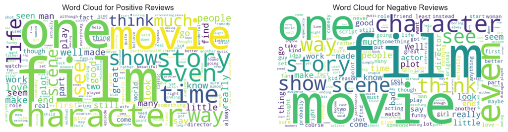

```python
from wordcloud import WordCloud
import matplotlib.pyplot as plt

# Create word cloud for positive and negative
positive_words = ' '.join(df[df['sentiment'] == 'positive']['cleaned_review'])
negative_words = ' '.join(df[df['sentiment'] == 'negative']['cleaned_review'])

# Generate word clouds
wc_pos = WordCloud(width=800, height=400, background_color='white').generate(positive_words)
wc_neg = WordCloud(width=800, height=400, background_color='white').generate(negative_words)

# Display side by side
plt.figure(figsize=(14, 6))
plt.subplot(1, 2, 1)
plt.imshow(wc_pos, interpolation='bilinear')
plt.axis('off')
plt.title('Word Cloud for Positive Reviews')

plt.subplot(1, 2, 2)
plt.imshow(wc_neg, interpolation='bilinear')
plt.axis('off')
plt.title('Word Cloud for Negative Reviews')

plt.show()
```

**Interpretations**

1. Observations
- Shared high-frequency terms: *film*, *movie*, *character*, *scene*; common across sentiments
- Positive: Words like *story*, *love*, *great*, *perfect*, *good*, *character*; affirming tone.
- Negative: Words like *bad*, *dull*, *boring*, *waste*, *worst*, *terrible*; disapproving tone.
- These visualizations show lexical overlap, but also strong sentiment-specific terms.

### KEY INSIGHTS AND RECOMMENDATIONS

- Key findings summary
- Recommendations for future iterations of this project
- Recommendations for the Data Visualizer team member

#### **Key Findings Summary**

*EDA Insights*

1. Word clouds validated model understanding by highlighting emotionally polarized words in positive/negative reviews.
2. Common terms like "film" and "movie" appears in both classes, supporting the need for contextual models like DistilBERT to resolve ambiguity.

#### **Recommendations for Future Project Iterations**

1. Integrate explainability for DistilBERT to expose how BERT variants arrive at predictions and uncover semantic patterns.
2. Explore domain adaptation for fine-tuning (i.e., Rotten Tomatoes, YouTube comments) to improve accuracy, generalization, and context-awareness.
3. Incorporate additional metadata features to test if hybrid models (structured + unstructured) yield stronger results.
4. Try dimensionality reduction for tree-based models as it could potentially improve tree model performance and reduce runtime.
5. Deploy and monitor with live data for model drift detection.

#### **Recommendations for Data Visualizer**

1. Unify ROC, Confusion Matrix, and SHAP for All Models into a Dashboard
   - Create a side-by-side visual comparison of model performance using Plotly, Dash, Altair, or Matplotlib Subplots to support stakeholder model selection.
2. Build an Interactive SHAP Explorer
   - Allows users to explore word-level SHAP values dynamically by sentence or prediction class to reveal unexpected patterns (i.e., sarcasm, negation).
3. Improve Word Cloud Clarity
   - Pre-procesdss with more targeted token filtering: remove stopwords and filler terms (i.e., film, movie) or scale by SHAP impact, not just frequency.
4. Sentiment Distribution by SHAP Impact Plot (Beeswarm or Bar Plot)
   - Create a visualization that shows global importance of features (words or engineered features) uusing SHAP summary plots.
5. Prepare Polished Outputs for Reporting or Publication
   - Export all final visuals in vector format (SVG/PDF) with clear annotations, legends, and accessibility-aware color palettes for use in academic papers, blog posts, or presentations.

# Data Visualizer

**Data Visualizer**:  
Carlos Escamilla

### Visualization Plots

1. **Sentiment Distribution Plot**
2. **Adjectives/Adverbs Distribution**
3. **Review Length Box Plot**
4. **Review Length Distribution**
5. **POS Count vs Review Length Scatter**
6. **Average POS Count Bar Plot**

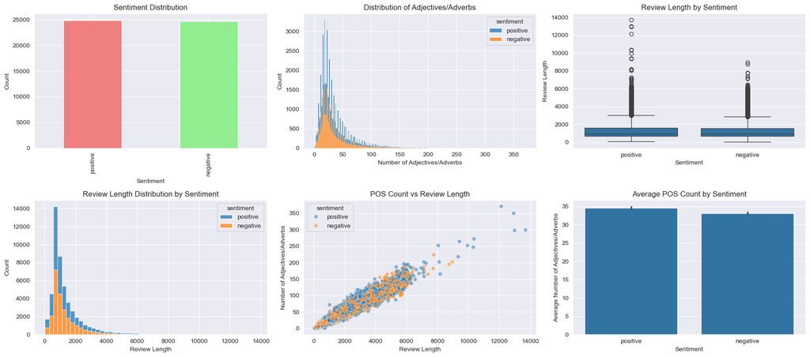

```python
import seaborn as sns
import matplotlib.pyplot as plt

# Calculate the review length and add it to the DataFrame
df['review_length'] = df['review'].apply(len)

# Create a figure with 6 subplots (2 rows, 3 columns)
plt.figure(figsize=(18, 8))

# Plot 1: Sentiment Distribution (Original)
plt.subplot(2, 3, 1)
df['sentiment'].value_counts().plot(kind='bar', color=['lightcoral', 'lightgreen'])
plt.title('Sentiment Distribution')
plt.xlabel('Sentiment')
plt.ylabel('Count')

# Plot 2: Distribution of POS tags (Original)
plt.subplot(2, 3, 2)
sns.histplot(data=df, x='pos_count', hue='sentiment', multiple="stack")
plt.title('Distribution of Adjectives/Adverbs')
plt.xlabel('Number of Adjectives/Adverbs')
plt.ylabel('Count')

# Plot 3: Review Length by Sentiment (Original)
plt.subplot(2, 3, 3)
sns.boxplot(data=df, x='sentiment', y='review_length')
plt.title('Review Length by Sentiment')
plt.xlabel('Sentiment')
plt.ylabel('Review Length')

# Plot 4: Review Length Distribution
plt.subplot(2, 3, 4)
sns.histplot(data=df, x='review_length', hue='sentiment', multiple="stack", bins=50)
plt.title('Review Length Distribution by Sentiment')
plt.xlabel('Review Length')
plt.ylabel('Count')

# Plot 5: POS Count vs Review Length
plt.subplot(2, 3, 5)
sns.scatterplot(data=df, x='review_length', y='pos_count', hue='sentiment', alpha=0.5)
plt.title('POS Count vs Review Length')
plt.xlabel('Review Length')
plt.ylabel('Number of Adjectives/Adverbs')

# Plot 6: Average POS Count by Sentiment
plt.subplot(2, 3, 6)
sns.barplot(data=df, x='sentiment', y='pos_count', errorbar=('ci', 95))
plt.title('Average POS Count by Sentiment')
plt.xlabel('Sentiment')
plt.ylabel('Average Number of Adjectives/Adverbs')

plt.tight_layout()
plt.show()
```